# Batch Correction

ALSF CCDL - Candace Savonen

*Purpose*: This notebook illustrates how to assess batch effects and how to use `limma` to batch correct.

The [refine.bio normalization pipeline](http://docs.refine.bio/en/latest/main_text.html) completed prior to your download, may be sufficient for removing batch effects for many datasets. It is good practice to assess for batch effects regardless, especially if your dataset consists of more than one type of platform.

In this example, we will use expression data collected from Acute Myeloid Leukemia patients.

This aggregated dataset consists of four original datasets we aggregated by species on refine.bio.

GSE6891 GSE14468 SRP048759 SRP033266

## 1) Set up

This will install `limma` for you if you haven’t installed it before. We recommend looking through [`limma`’s guide](https://bioconductor.org/packages/release/bioc/vignettes/limma/inst/doc/usersguide.pdf) for further information.

```r
if (!("limma" %in% installed.packages())) {
  # Install limma
  BiocManager::install("limma", update = FALSE)
}
```

```r
# Make a results directory if it isn't created yet
if (!dir.exists("results")) {
  dir.create("results")
}
# Make a plots directory if it isn't created yet
if (!dir.exists("plots")) {
  dir.create("plots")
}
```

```r
# Make a results directory if it isn't created yet
if (!dir.exists("results")) {
  dir.create("results")
}
# Make a plots directory if it isn't created yet
if (!dir.exists("plots")) {
  dir.create("plots")
}
```

## 2) Import and set up data

Data downloaded from refine.bio include a metadata tab separated values (“tsv”) file and a data tsv file. These files were obtained from [refine.bio](https://www.refine.bio/) by entering the search term “AML” and then aggregating by `species`.

```r
# Put name of data file
data.filename <- file.path( "data", "HOMO_SAPIENS.tsv")
# Unzip the file and direct it to the data folder
unzip(paste0(data.filename, ".zip"), exdir = "data")
```

```
error 1 in extracting from zip file
```

```r
# Read in data tsv file
df <- readr::read_tsv(data.filename, progress = FALSE) %>%
  tibble::column_to_rownames('Gene')
```

```
Setting row names on a tibble is deprecated.
```

```r
# Make the gene column the rownames so the gene names are out of the way for calculations
```

Prep metadata to be in proper format for batch info to be used by ComBat

```r
# Metadata file name
metadata.filename <- file.path("data", "metadata_HOMO_SAPIENS.tsv")
# Read in data tsv file
metadata <- readr::read_tsv(metadata.filename, progress = FALSE)
# Put samples in the same order in the dataframe
df <- df %>% dplyr::select(metadata$refinebio_accession_code)
# Check if the samples are in the same order
all.equal(metadata$refinebio_accession_code, colnames(df))
```

```
[1] TRUE
```

## 3) Set up batch information.

For this batch correction, we will want both original dataset information as well as platform information.

Set up the platform information.

```r
# Get rid of spaces to streamline things
metadata$refinebio_platform <- gsub(" ", "", metadata$refinebio_platform)

# Make into a factor
platform <- as.factor(metadata$refinebio_platform)
```

Set up the dataset of origin information.

```r
# Make a dataset vector
dataset <- metadata$series_id
# Fill in the NA's for the dataset that isn't included in this variable
dataset[is.na(dataset)] <- "SRP048759"
# Make this a factor
dataset <- as.factor(dataset)
```

## 4) Perform Principal Components Analysis

```r
# Calculate PCA
pca <- prcomp(t(df))
# Make into dataframe for plotting with ggplot2
pca.df <- data.frame(pca$x[, 1:2])
```

Plot these PC scores and look for how samples of different platforms and datasets cluster.

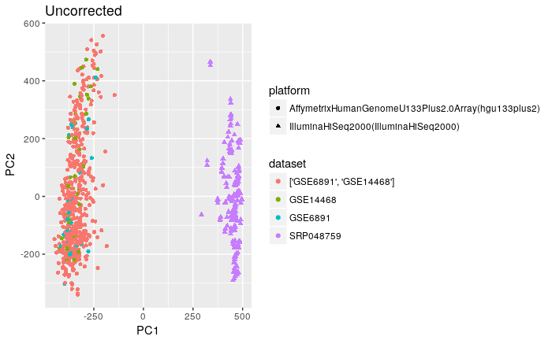

```r
# Create a scatterplot
pc.plot <- ggplot(pca.df, aes(x = PC1, y = PC2, color = dataset,
                              shape = platform)) +
  geom_point() +
  ggtitle("Uncorrected")
# Print out the plot here
pc.plot
```

Save plot to a png.

```r
# Save the plot to a png
ggsave(file.path("plots", "uncorrected_pc_plot.png"))
```

```r
# Use removeBatchEffect function from limma
corrected.df <- limma::removeBatchEffect(df, batch =  platform)
```

## 6) Re-evaluate PCA after batch correction

Let’s see if batch correction helped with making PC scores less divided by batches.

```r
# Calculate PCA
corrected.pca <- prcomp(t(corrected.df))
# Make into dataframe for plotting with ggplot2
corrected.pca.df <- data.frame(corrected.pca$x[, 1:2])
```

Plot these batch corrected data PC scores.

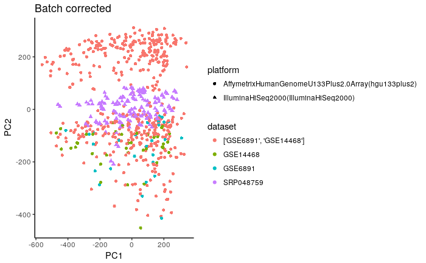

```r
# Create a scatterplot
pc.plot <- ggplot(corrected.pca.df, aes(x = PC1, y = PC2, color = dataset,
                                        shape = platform)) +
  geom_point() +
  ggtitle("Batch corrected") +
  theme_classic()
# Print out the plot here
pc.plot
```

Although the correction doesn’t completely get rid of the batch effects on PC2, It clearly reduces the effect of the batch effect on PC1. This an example of how batch correction can help, but will probably not get rid of the problem entirely. Depending on what analyses these data were being used for, we would consider analyzing these datasets separately, or moving forward with only samples of one platform type.

Save plot with batch corrected PCA plot to a png.

```r
ggsave(file.path("plots", "batch_corrected_pca_plot.png"))
```

## 7) Save batch corrected data to tsv file

We will save the batch corrected dataframe to a tsv file for hypothetical future use.

```r
corrected.df %>% as.data.frame() %>%
  tibble::rownames_to_column("Gene") %>%
  readr::write_tsv(file.path("results", "batch_corrected_exprs.tsv"))
```

Session info:

```r
# Print session info
sessionInfo()
```

[output not shown]